# Life satisfaction across Europe

Eurobarometer results from May-June, 2023

## Aim

I will also try to demonstrate some of the features of R statistical language for handling SPSS format data files.

## About Eurobarometer

Eurobarometer is the oldest ongoing survey series conducted regularly in Europe. It is requested and coordinated by the European Commission. The datasets are public and available via two leading data archive: GESIS (formerly Zentral Archive) and the ICPSR. The Eurobarometer 99.4 ([ZA No. 7997](https://search.gesis.org/research_data/ZA7997?doi=10.4232/1.14167)) was carried out in May-June 2023 by the Kantar Group.

Main topics of the survey are:

- Standard trend questions (QA)
- Europeans’ priorities (QB)
- The EU and the Coronavirus pandemic (QC)
- European citizenship (QD)
- The EU’s response to the war in Ukraine (QE)

Note that Qs in parens refer to variable (column) names / question blocks. Beside a bunch of population size weights, the dataset contains a post-stratification weight (w1). It adjusts the sample marginals to known population characteristics. These are sex, age, region and size of locality. The data presented here are always weighted.

## Handling SPSS data attributes in R

SPSS stores data in a format that can have attributes like descriptive variable labels, value labels and different forms of missing values. These features are not available in base R, but via dedicated packages. [{memisc}](https://www.rdocumentation.org/packages/memisc/versions/0.99.31.7/topics/Memisc) and {haven} are probably the most well-known. In the followings I will use the later together with {labelled}.

## Weighting survey data in R

R provides many ways to do weighted analyses. The basic ones are `wtd.mean`, `wtd.table` from {questionr} and {dplyr} `count` has also a weight (wt) option. If you are working with complex survey designs, see `{survey}` package.

## Read and look into data

Read the data and have look into it.

```r
library(haven)
df <- read_spss(file = "ZA7997_v1-0-0.sav", col_select = c("isocntry", "country", "d70", "w1"))
knitr::kable(head(df, n=5))
```

| country | isocntry | d70 | w1 |
| --- | --- | --- | --- |
| 37 | AL | 3 | 0.8007330 |
| 37 | AL | 3 | 0.5367798 |
| 37 | AL | 2 | 0.5218543 |
| 37 | AL | 2 | 0.6365653 |
| 37 | AL | 4 | 0.6365653 |

GESIS provides all documentations that are needed for understanding the content of the dataset we use. Study description, background and national questionnaires with technical infos are available. However, the variable names in the data file are different from that of in questionnaire. This is where the function `labelled::look_for()` is handy as it produces nice codebook on screen just like SPSS’s `display dictionary`.

The original life satisfaction question (d70) was on a four-point Likert-scale with an option for DONT KNOW (DK) answer:

“On the whole, are you (1) very satisfied, (2) fairly satisfied, (3) not very satisfied or (4) not at all satisfied with the life you lead?”

We shall focus on those who are (1) “very”, or (2) “fairly satisfied”. So we need to create two additional variables, “total satisfaction”, that summarise these categories, and another for country groups.

```r
library(dplyr)
library(labelled)
df2 <- df %>%
    count(isocntry, d70, wt = w1) %>% # weighted table and keep all columns
    mutate(perc=n/sum(n)*100, .by = isocntry, .keep = "all") # USE .by, otherwise works on ungrouped, produces total pcts

df2$totsat <- ifelse(df2$d70 < 3, 1, 0)
df2$totsat <- set_value_labels(df2$totsat, c(satisfied = 1, "non-satisfied" = 0))

df2
```

| isocntry | d70 | n | perc | totsat |
| --- | --- | --- | --- | --- |
| AL | 1 | 146.6711083 | 14.59414012 | 1 |
| AL | 2 | 473.6612411 | 47.13047176 | 1 |
| AL | 3 | 324.7851040 | 32.31692577 | 0 |
| AL | 4 | 59.8825466 | 5.95846235 | 0 |
| AT | 1 | 306.6393605 | 30.48104975 | 1 |
| AT | 2 | 569.5341078 | 56.61372841 | 1 |
| AT | 3 | 104.8152750 | 10.41901342 | 0 |
| AT | 4 | 25.0112566 | 2.48620841 | 0 |
| BA | 1 | 128.6774012 | 12.82925236 | 1 |
| BA | 2 | 628.7339647 | 62.68534045 | 1 |

[output cut: 170 more lines]

Lets have look the distribution of satisfaction variable (d70) across all countries.

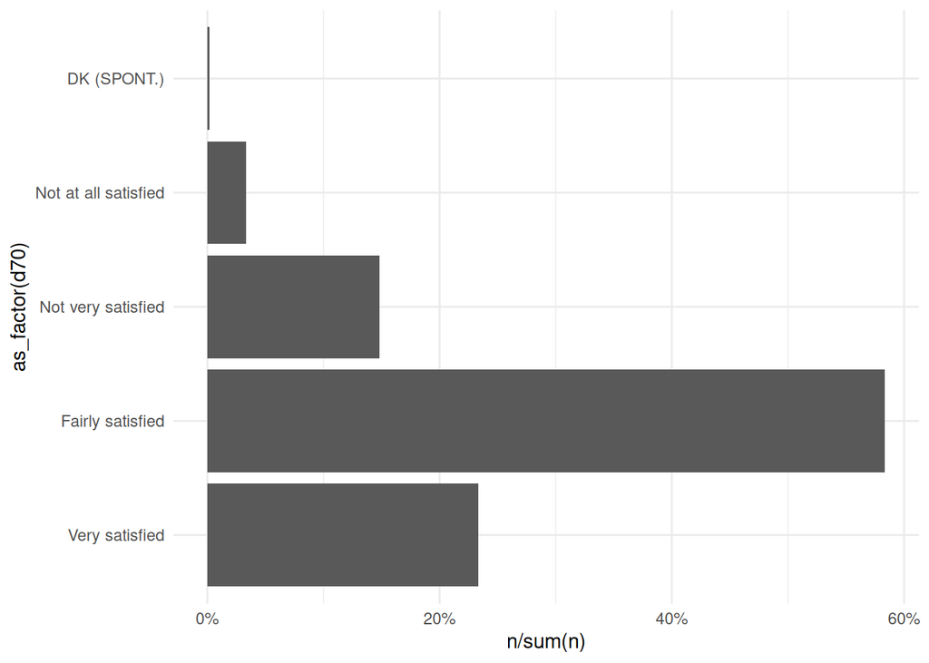

```r
library(ggplot2)
library(scales)
ggplot(df2, aes(x=n/sum(n), y=as_factor(d70))) + geom_bar(stat = "identity") +
    scale_x_continuous(labels = label_percent()) +
    theme_minimal()
```

Satisfaction by country table: Number of cases

```r
library(tidyr)
ct1 <- df %>%
    group_by(d70, isocntry) %>%
    tally(wt = w1) %>%
    pivot_wider(names_from = d70, values_from = n, names_prefix = "sat") %>%
    rowwise(isocntry) %>%
    mutate(RowSum=sum(across(sat1:sat5), na.rm = TRUE))
knitr::kable(ct1, digits = 0)
```

| isocntry | sat1 | sat2 | sat3 | sat4 | sat5 | RowSum |
| --- | --- | --- | --- | --- | --- | --- |
| AL | 147 | 474 | 325 | 60 | NA | 1005 |
| AT | 307 | 570 | 105 | 25 | NA | 1006 |
| BA | 129 | 629 | 217 | 26 | 2 | 1003 |
| BE | 208 | 664 | 122 | 21 | NA | 1014 |
| BG | 98 | 529 | 309 | 79 | 13 | 1028 |
| CH | 384 | 594 | 62 | 10 | NA | 1050 |
| CY | 180 | 252 | 63 | 10 | NA | 504 |
| CY-TCC | 147 | 198 | 79 | 79 | 1 | 505 |
| CZ | 218 | 712 | 87 | 17 | 1 | 1035 |
| DE-E | 109 | 303 | 82 | 17 | 2 | 513 |
| DE-W | 246 | 697 | 81 | 12 | 4 | 1040 |
| DK | 696 | 284 | 27 | 2 | 6 | 1016 |
| EE | 162 | 671 | 139 | 19 | 11 | 1002 |
| ES | 296 | 587 | 113 | 18 | NA | 1014 |
| FI | 390 | 559 | 46 | 5 | 3 | 1003 |
| FR | 204 | 662 | 118 | 29 | 1 | 1014 |
| GB | 368 | 577 | 74 | 15 | 1 | 1035 |
| GR | 118 | 555 | 248 | 92 | NA | 1013 |
| HR | 174 | 650 | 151 | 28 | NA | 1003 |
| HU | 106 | 709 | 183 | 23 | NA | 1021 |
| IE | 519 | 451 | 29 | NA | 3 | 1002 |
| IT | 80 | 727 | 202 | 22 | 3 | 1033 |
| LT | 225 | 592 | 176 | 15 | 0 | 1008 |
| LU | 190 | 294 | 21 | 2 | NA | 506 |
| LV | 138 | 690 | 166 | 30 | 1 | 1024 |
| MD | 107 | 546 | 265 | 82 | 5 | 1006 |
| ME | 54 | 297 | 153 | 19 | NA | 522 |
| MK | 97 | 632 | 228 | 79 | NA | 1036 |
| MT | 132 | 344 | 34 | 1 | NA | 512 |
| NL | 513 | 434 | 50 | 4 | NA | 1001 |
| NO | 271 | 654 | 104 | 19 | 2 | 1050 |
| PL | 153 | 763 | 67 | 16 | 8 | 1007 |
| PT | 39 | 786 | 169 | 10 | 1 | 1004 |
| RO | 101 | 563 | 324 | 68 | NA | 1056 |
| RS | 80 | 522 | 339 | 76 | NA | 1017 |
| RS-KM | 266 | 595 | 126 | 57 | NA | 1044 |
| SE | 475 | 502 | 40 | 8 | NA | 1025 |
| SI | 298 | 636 | 65 | 10 | 1 | 1009 |
| SK | 187 | 595 | 192 | 25 | 1 | 1001 |
| TR | 172 | 498 | 210 | 122 | NA | 1003 |

Satisfaction by country table: Percentages within countries (“Row percentages”)

```r
ct2 <- ct1 %>%
    mutate(sat1p = (sat1/RowSum)*100,
           sat2p = (sat2/RowSum)*100,
           sat3p = (sat3/RowSum)*100,
           sat4p = (sat4/RowSum)*100,
           sat5p = (sat5/RowSum)*100,
           PercTotal = sum(across(ends_with("p")), na.rm = TRUE), .keep = "none")
knitr::kable(ct2, digits = 0)
```

| isocntry | sat1p | sat2p | sat3p | sat4p | sat5p | PercTotal |
| --- | --- | --- | --- | --- | --- | --- |
| AL | 15 | 47 | 32 | 6 | NA | 100 |
| AT | 30 | 57 | 10 | 2 | NA | 100 |
| BA | 13 | 63 | 22 | 3 | 0 | 100 |
| BE | 20 | 65 | 12 | 2 | NA | 100 |
| BG | 10 | 51 | 30 | 8 | 1 | 100 |
| CH | 37 | 57 | 6 | 1 | NA | 100 |
| CY | 36 | 50 | 12 | 2 | NA | 100 |
| CY-TCC | 29 | 39 | 16 | 16 | 0 | 100 |
| CZ | 21 | 69 | 8 | 2 | 0 | 100 |
| DE-E | 21 | 59 | 16 | 3 | 0 | 100 |
| DE-W | 24 | 67 | 8 | 1 | 0 | 100 |
| DK | 69 | 28 | 3 | 0 | 1 | 100 |
| EE | 16 | 67 | 14 | 2 | 1 | 100 |
| ES | 29 | 58 | 11 | 2 | NA | 100 |
| FI | 39 | 56 | 5 | 0 | 0 | 100 |
| FR | 20 | 65 | 12 | 3 | 0 | 100 |
| GB | 36 | 56 | 7 | 1 | 0 | 100 |
| GR | 12 | 55 | 24 | 9 | NA | 100 |
| HR | 17 | 65 | 15 | 3 | NA | 100 |
| HU | 10 | 69 | 18 | 2 | NA | 100 |
| IE | 52 | 45 | 3 | NA | 0 | 100 |
| IT | 8 | 70 | 20 | 2 | 0 | 100 |
| LT | 22 | 59 | 17 | 1 | 0 | 100 |
| LU | 38 | 58 | 4 | 0 | NA | 100 |
| LV | 13 | 67 | 16 | 3 | 0 | 100 |
| MD | 11 | 54 | 26 | 8 | 1 | 100 |
| ME | 10 | 57 | 29 | 4 | NA | 100 |
| MK | 9 | 61 | 22 | 8 | NA | 100 |
| MT | 26 | 67 | 7 | 0 | NA | 100 |
| NL | 51 | 43 | 5 | 0 | NA | 100 |
| NO | 26 | 62 | 10 | 2 | 0 | 100 |
| PL | 15 | 76 | 7 | 2 | 1 | 100 |
| PT | 4 | 78 | 17 | 1 | 0 | 100 |
| RO | 10 | 53 | 31 | 6 | NA | 100 |
| RS | 8 | 51 | 33 | 8 | NA | 100 |
| RS-KM | 25 | 57 | 12 | 5 | NA | 100 |
| SE | 46 | 49 | 4 | 1 | NA | 100 |
| SI | 30 | 63 | 6 | 1 | 0 | 100 |
| SK | 19 | 59 | 19 | 3 | 0 | 100 |
| TR | 17 | 50 | 21 | 12 | NA | 100 |

```r
postcom <- c("DE-E", "CZ", "EE", "HU", "LV", "LT", "PL", "SK", "SI", "BG", "RO",
             "HR", "MK", "ME", "RS", "AL", "MD", "BA", "RS-KM")
ct2$com <- ifelse(ct2$isocntry %in% postcom, "Post-communist", "Other")
```

Create a plot for “very satisfied”

[output not shown]

[figure not shown]

```r
ct3 <- ct2 %>%
    select(c(isocntry, sat1p, sat2p)) %>%
    mutate(totsat = sat1p + sat2p) %>%
    arrange(totsat) %>%
    pivot_longer(cols = c("sat1p", "sat2p"), names_to = "sat", values_to = "value")
ct3
```

| isocntry | totsat | sat | value |
| --- | --- | --- | --- |
| RS | 59.19110 | sat1p | 7.896961 |
| RS | 59.19110 | sat2p | 51.294134 |
| BG | 61.00526 | sat1p | 9.533657 |
| BG | 61.00526 | sat2p | 51.471604 |
| AL | 61.72461 | sat1p | 14.594140 |
| AL | 61.72461 | sat2p | 47.130472 |
| RO | 62.88674 | sat1p | 9.534129 |
| RO | 62.88674 | sat2p | 53.352609 |
| MD | 64.96148 | sat1p | 10.653028 |
| MD | 64.96148 | sat2p | 54.308450 |

[output cut: 70 more lines]

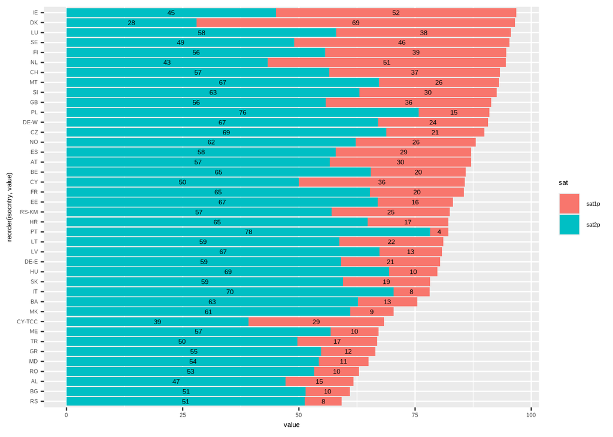